# p66 Reverse transcriptase / P51 RT

Fold-switch pair **3meeA_4b3oB** — **3meeA** vs **4b3oB**

HIV-1 M:B_HXB2R / Human immunodeficiency virus 1

## Figure 1: Phylogenetic tree with per-cluster fold-preference heatmap.

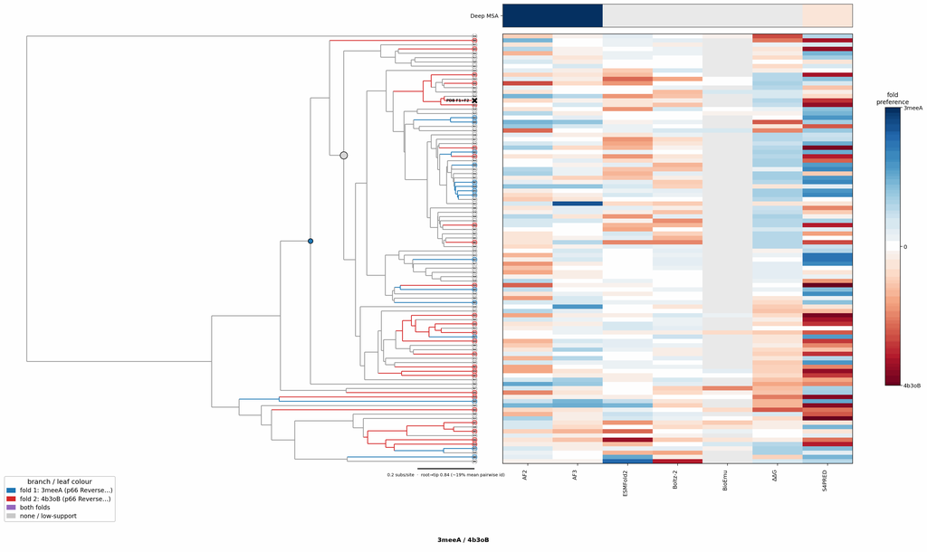

## Figure 2: Aligned overlay (both folds superposed)

The single fold-switching chain of each fold superposed by TM-align; waters hidden, any ligand shown as green sticks. Grey = structurally conserved core, colour = divergent (fold-switching) region.

3meeA (p66 Reverse transcriptase / P51 RT) · dimer4b3oB (p66 Reverse transcriptase / P51 RT) · tetramerLigand T27 (bound to 3meeA), Ligand 3DR|EFZ (bound to 4b3oB)

TM-score: 0.454 · Trigger class: ligand

Aligned overlay

## Figure 3: The two folds, side by side

Each fold is coloured by per-residue Cα deviation between the two superposed structures: grey ≈ conserved core, full colour = structurally divergent (fold-switching) region.

3meeA (p66 Reverse transcriptase / P51 RT)

4b3oB (p66 Reverse transcriptase / P51 RT)

0 Å5≥10 Å

3meeA (p66 Reverse transcriptase / P51 RT)

4b3oB (p66 Reverse transcriptase / P51 RT)

## Figure 4: Best-cluster predicted contact maps over the two true folds.

Predicted contact maps (MSA-Transformer) for the clusters best matching each fold, over the true contacts of fold 1 (upper triangle) and fold 2 (lower). Divergent contacts between clusters are the contact-level signature of fold-switching.

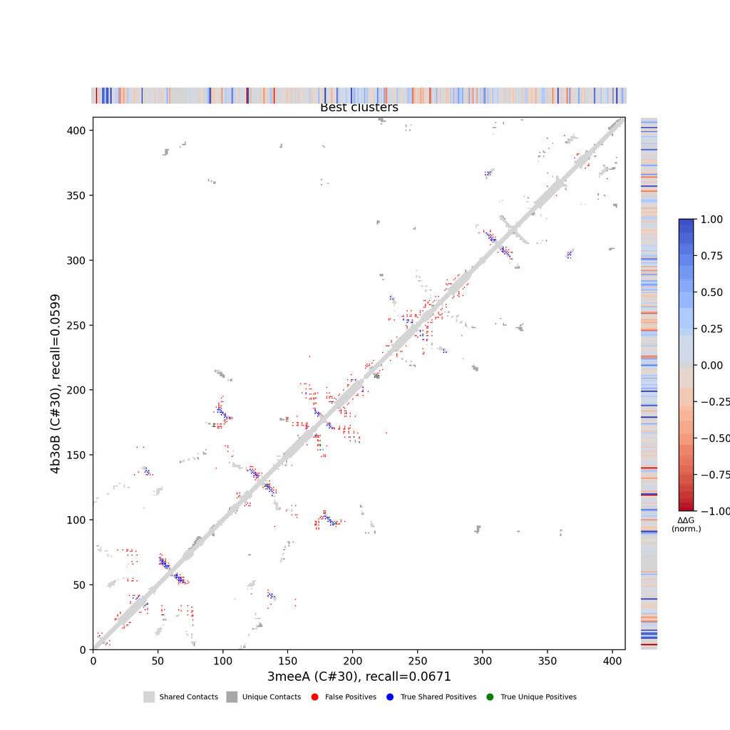

## Figure 5: Per-residue ΔΔG fold-preference contribution

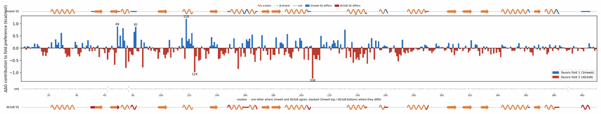

**More figures**

## Figure 6: Deep-MSA contact map panel / Best clusters contact map panel

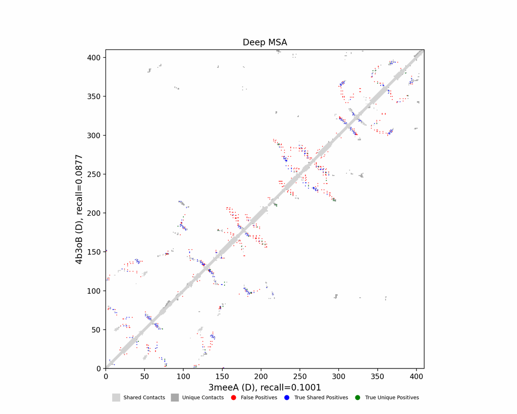

Deep-MSA contact map panel

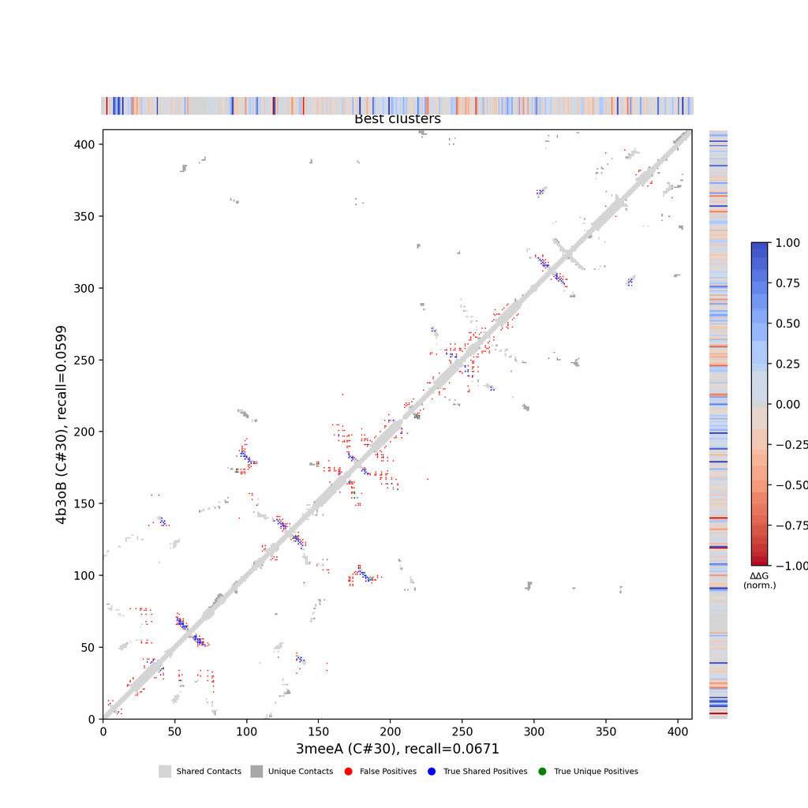

Best clusters contact map panel

## Figure 7: All clusters contact-map mosaic (small multiples).

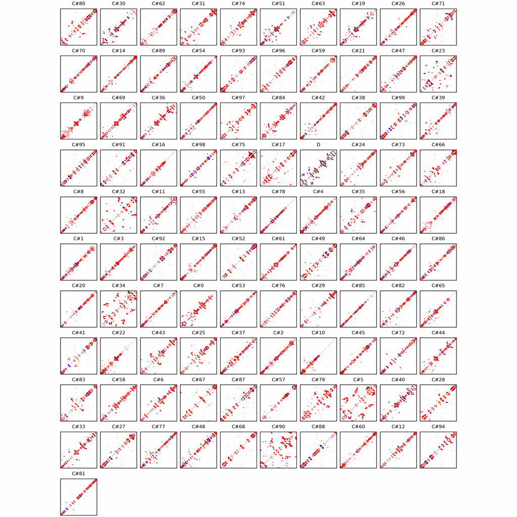

## Figure 8: Phylo null: tree with shuffled cluster fold labels.

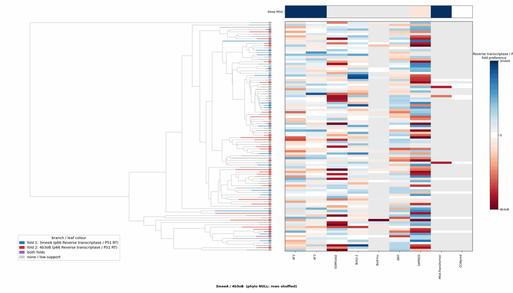

## Cluster metrics table

Per-cluster metrics underlying the figures above.

| cluster | n | neff | AF2_TM1 | AF2_TM2 | AF3_TM1 | AF3_TM2 | RE-MSAT-COM | RE-MSAT1 | RE-MSAT2 | ESM_SEQIDS | ESM_TM1 | ESM_TM2 | ΔΔG_Bias | ΔΔG_Bias_std | ΔΔG_frac_F1 | Boltz2_pref | S4PRED_pref | CCMpred_pref | BioEmu_pref |
| --- | --- | --- | --- | --- | --- | --- | --- | --- | --- | --- | --- | --- | --- | --- | --- | --- | --- | --- | --- |
| Deep | - | - | 0.62 | 0.48 | 0.82 | 0.46 | 0.3 | 0.31 | 0.26 | - | - | - | - | - | - | - | -0.0 | 0.0 | - |
| 000 | 304.0 | 141.0 | 0.4 | 0.34 | 0.48 | 0.49 | 0.0 | 0.0 | 0.0 | 002; 002; 003; 003; 010; 010; 001; 001; 004; 004 | 0.51 ± 0.10 | 0.46 ± 0.05 | -52.27 | 29.13 | 0.0 | -0.04 | -0.02 | 0.0 | - |
| 001 | 293.0 | 10.0 | 0.24 | 0.26 | 0.3 | 0.31 | 0.02 | 0.01 | 0.02 | 002; 002; 001; 001; 003; 003; 009; 009; 006; 006 | 0.57 ± 0.12 | 0.48 ± 0.04 | -17.99 | 12.79 | 0.0 | -0.08 | 0.01 | 0.0 | - |
| 002 | 269.0 | 3.0 | 0.19 | 0.23 | 0.28 | 0.32 | 0.0 | 0.0 | 0.0 | 001; 001; 002; 002; 007; 007; 003; 003; 006; 006 | 0.56 ± 0.09 | 0.45 ± 0.01 | -3.69 | 2.74 | 0.0 | -0.08 | -0.02 | 0.0 | - |
| 003 | 241.0 | 8.0 | 0.19 | 0.19 | 0.22 | 0.23 | 0.0 | 0.0 | 0.0 | 006; 006; 001; 001; 003; 003; 007; 007; 008; 008 | 0.37 ± 0.04 | 0.41 ± 0.02 | -5.64 | 5.01 | 0.0 | -0.05 | -0.01 | 0.0 | - |
| 004 | 136.0 | 5.0 | 0.27 | 0.21 | 0.42 | 0.33 | 0.0 | 0.01 | 0.0 | 003; 003; 002; 002; 008; 008; 001; 001; 004; 006 | 0.61 ± 0.05 | 0.47 ± 0.03 | -10.58 | 13.1 | 0.2 | -0.15 | -0.0 | 0.0 | - |
| 005 | 98.0 | 73.0 | 0.43 | 0.41 | 0.43 | 0.45 | 0.01 | 0.01 | 0.03 | 002; 001; 002; 001; 006; 006; 004; 004; 003; 003 | 0.56 ± 0.11 | 0.46 ± 0.07 | -17.66 | 4.95 | 0.0 | -0.04 | 0.02 | 0.0 | - |
| 006 | 93.0 | 55.0 | 0.34 | 0.37 | 0.58 | 0.48 | 0.02 | 0.02 | 0.02 | 001; 001; 007; 008; 008; 006; 007; 006; 009; 009 | 0.51 ± 0.03 | 0.44 ± 0.01 | -32.69 | 11.74 | 0.0 | -0.08 | -0.01 | 0.0 | - |
| 007 | 91.0 | 3.0 | 0.23 | 0.24 | 0.22 | 0.24 | 0.0 | 0.01 | 0.0 | 003; 003; 004; 005; 005; 004; 002; 002; 006; 006 | 0.67 ± 0.05 | 0.49 ± 0.01 | -3.35 | 3.18 | 0.1 | -0.12 | 0.01 | 0.0 | - |
| 008 | 79.0 | 5.0 | 0.26 | 0.22 | 0.26 | 0.32 | 0.0 | 0.0 | 0.0 | 002; 002; 001; 001; 003; 003; 005; 004; 005; 004 | 0.62 ± 0.06 | 0.45 ± 0.10 | -2.34 | 2.65 | 0.1 | -0.04 | 0.0 | 0.0 | - |
| 009 | 78.0 | 1.0 | 0.38 | 0.33 | 0.62 | 0.49 | 0.0 | 0.0 | 0.0 | 003; 003; 001; 004; 001; 004; 005; 005; 010; 010 | 0.61 ± 0.09 | 0.44 ± 0.07 | -56.5 | 40.51 | 0.0 | -0.04 | 0.02 | 0.0 | - |
| 010 | 74.0 | 64.0 | 0.24 | 0.33 | 0.45 | 0.48 | 0.0 | 0.0 | 0.0 | - | - | - | -21.05 | 6.75 | 0.0 | -0.06 | -0.03 | - | - |
| 011 | 71.0 | 5.0 | 0.27 | 0.28 | 0.44 | 0.41 | 0.03 | 0.03 | 0.03 | - | - | - | -7.16 | 5.72 | 0.0 | -0.15 | -0.03 | - | - |
| 012 | 70.0 | 17.0 | 0.27 | 0.26 | 0.28 | 0.28 | 0.0 | 0.0 | 0.0 | - | - | - | -34.88 | 11.58 | 0.0 | -0.08 | -0.02 | - | - |
| 013 | 70.0 | 10.0 | 0.26 | 0.26 | 0.23 | 0.28 | 0.0 | 0.0 | 0.0 | - | - | - | -30.48 | 6.66 | 0.0 | -0.06 | 0.02 | - | - |
| 014 | 69.0 | 3.0 | 0.2 | 0.22 | 0.19 | 0.23 | 0.0 | 0.0 | 0.0 | - | - | - | -4.6 | 6.11 | 0.1 | -0.06 | -0.02 | - | -0.03 |
| 015 | 68.0 | 1.0 | 0.22 | 0.19 | 0.24 | 0.28 | 0.0 | 0.0 | 0.0 | - | - | - | -22.8 | 11.59 | 0.0 | -0.06 | 0.02 | - | -0.05 |
| 016 | 66.0 | 4.0 | 0.27 | 0.26 | 0.25 | 0.24 | 0.02 | 0.01 | 0.01 | - | - | - | -7.34 | 6.29 | 0.2 | -0.1 | 0.02 | - | - |
| 017 | 62.0 | 24.0 | 0.29 | 0.31 | 0.52 | 0.48 | 0.0 | 0.01 | 0.0 | - | - | - | -20.86 | 6.39 | 0.0 | -0.04 | 0.03 | - | - |
| 018 | 61.0 | 1.0 | 0.21 | 0.23 | 0.22 | 0.24 | 0.0 | 0.0 | 0.0 | - | - | - | -16.46 | 14.36 | 0.0 | -0.03 | 0.02 | - | -0.05 |
| 019 | 59.0 | 7.0 | 0.42 | 0.37 | 0.61 | 0.49 | 0.08 | 0.05 | 0.06 | - | - | - | -29.33 | 24.5 | 0.0 | -0.13 | 0.01 | - | - |
| 020 | 59.0 | 24.0 | 0.35 | 0.38 | 0.34 | 0.38 | 0.03 | 0.04 | 0.02 | - | - | - | -31.13 | 8.44 | 0.0 | -0.04 | -0.02 | - | - |
| 021 | 51.0 | 8.0 | 0.18 | 0.19 | 0.23 | 0.23 | 0.01 | 0.0 | 0.0 | - | - | - | -35.71 | 7.4 | 0.0 | -0.08 | -0.02 | - | -0.06 |
| 022 | 49.0 | 1.0 | 0.24 | 0.25 | 0.44 | 0.42 | 0.0 | 0.0 | 0.0 | - | - | - | -20.04 | 22.29 | 0.0 | -0.06 | 0.02 | - | - |
| 023 | 49.0 | 23.0 | 0.22 | 0.27 | 0.44 | 0.42 | 0.05 | 0.04 | 0.04 | - | - | - | -18.14 | 5.99 | 0.0 | -0.04 | 0.03 | - | - |
| 024 | 49.0 | 18.0 | 0.2 | 0.25 | 0.5 | 0.47 | 0.01 | 0.01 | 0.0 | - | - | - | -27.86 | 9.56 | 0.0 | -0.06 | -0.02 | - | - |
| 025 | 48.0 | 31.0 | 0.33 | 0.31 | 0.32 | 0.35 | 0.01 | 0.01 | 0.0 | - | - | - | -26.94 | 9.29 | 0.0 | -0.04 | -0.03 | - | - |
| 026 | 47.0 | 1.0 | 0.18 | 0.27 | 0.18 | 0.28 | 0.02 | 0.02 | 0.02 | - | - | - | -1.3 | 2.17 | 0.3 | -0.06 | 0.01 | - | -0.05 |
| 027 | 47.0 | 3.0 | 0.2 | 0.22 | 0.27 | 0.32 | 0.01 | 0.02 | 0.01 | - | - | - | -3.09 | 2.4 | 0.0 | -0.1 | -0.02 | - | - |
| 028 | 47.0 | 12.0 | 0.28 | 0.26 | 0.45 | 0.46 | 0.0 | 0.0 | 0.0 | - | - | - | -17.56 | 5.55 | 0.0 | -0.05 | -0.01 | - | - |

[output cut: 71 more lines]